# Project 1

```python
import pandas as pd
import numpy as np
import seaborn as sns
import matplotlib.pyplot as plt
```

## Introduction

The following datasets are collections of chemical characteristics of red and white vinho verde wine samples along with the overall quality of the wine sample. The dataset can be found at https://archive.ics.uci.edu/dataset/186/wine+quality

Import the files `winequality-white.csv` and `winequality-red.csv` as a dataframe named `white` and `red`, respectively.

```python
white = pd.read_csv('winequality-white.csv', sep = ';')
red = pd.read_csv('winequality-red.csv', sep = ';')
```

## Preprocessing

Create a function called `remove_outliers` that removes outliers from a dataframe using the 1.5*IQR method.

Use the `remove_outliers` function to remove any outliers from `white` and `red`.

```python
def remove_outliers(df):
    Q1 = df.quantile(0.25)
    Q3 = df.quantile(0.75)
    IQR = Q3 - Q1
    df_out = df[~((df < (Q1 - 1.5 * IQR)) | (df > (Q3 + 1.5 * IQR))).any(axis = 1)]
    return df_out

white = remove_outliers(white.select_dtypes(include = [np.number]))
red = remove_outliers(red.select_dtypes(include = [np.number]))
```

Since I want to analyze the characteristics of the combined datasets, I will remove outliers prior to combining them. Removing outliers after merging the datasets could disproportionally affect either set of data, affecting any consequent analysis.

Create a new column called `wine_type` to the `white` and `red` dataframes. Combine the two dataframes into one dataframe called `wine`.

```python
white['wine_type'] = 'white'
red['wine_type'] = 'red'

wine = pd.concat([white, red])
```

Remove any rows with missing values from `wine`.

```python
wine = wine.dropna()
```

## Summary Data Analysis

### Statistical Summary

Find the summary statistics for each quantitative variable in `wine`.

```python
wine.describe()
```

|  | fixed acidity | volatile acidity | citric acid | residual sugar | chlorides | free sulfur dioxide | total sulfur dioxide | density | pH | sulphates | alcohol | quality |
| --- | --- | --- | --- | --- | --- | --- | --- | --- | --- | --- | --- | --- |
| count | 5037.000000 | 5037.000000 | 5037.000000 | 5037.000000 | 5037.000000 | 5037.000000 | 5037.000000 | 5037.000000 | 5037.000000 | 5037.000000 | 5037.000000 | 5037.000000 |
| mean | 7.128956 | 0.324697 | 0.305950 | 5.408785 | 0.050942 | 30.120409 | 115.174509 | 0.994540 | 3.218817 | 0.516831 | 10.499715 | 5.815168 |
| std | 1.113448 | 0.150817 | 0.119913 | 4.686900 | 0.018869 | 16.174677 | 55.619411 | 0.002865 | 0.148287 | 0.120583 | 1.147178 | 0.754510 |
| min | 4.800000 | 0.080000 | 0.000000 | 0.600000 | 0.015000 | 1.000000 | 6.000000 | 0.987110 | 2.820000 | 0.220000 | 8.400000 | 4.000000 |
| 25% | 6.400000 | 0.220000 | 0.250000 | 1.800000 | 0.038000 | 17.000000 | 78.000000 | 0.992150 | 3.120000 | 0.430000 | 9.500000 | 5.000000 |
| 50% | 6.900000 | 0.280000 | 0.300000 | 2.800000 | 0.047000 | 29.000000 | 117.000000 | 0.994800 | 3.210000 | 0.500000 | 10.400000 | 6.000000 |
| 75% | 7.600000 | 0.380000 | 0.380000 | 8.100000 | 0.059000 | 41.000000 | 155.000000 | 0.996800 | 3.320000 | 0.590000 | 11.300000 | 6.000000 |
| max | 12.300000 | 1.005000 | 0.730000 | 22.000000 | 0.119000 | 80.000000 | 255.000000 | 1.001960 | 3.680000 | 0.980000 | 14.200000 | 7.000000 |

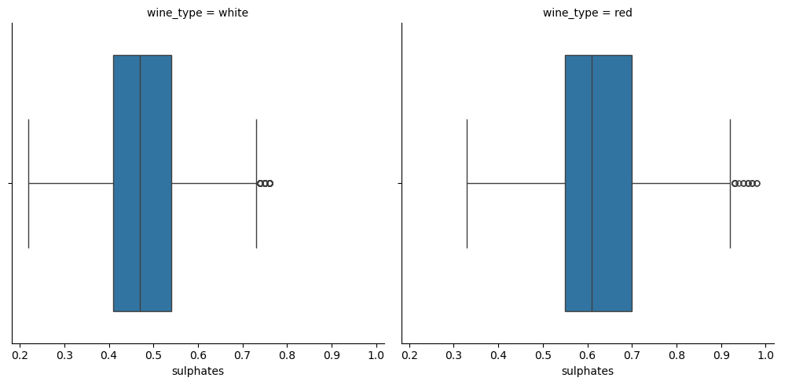

```python
sns.catplot(data = wine, x = 'sulphates', kind = 'box', col = 'wine_type')
```

The `sulphates` column has a lower distribution in white wine than red wine.

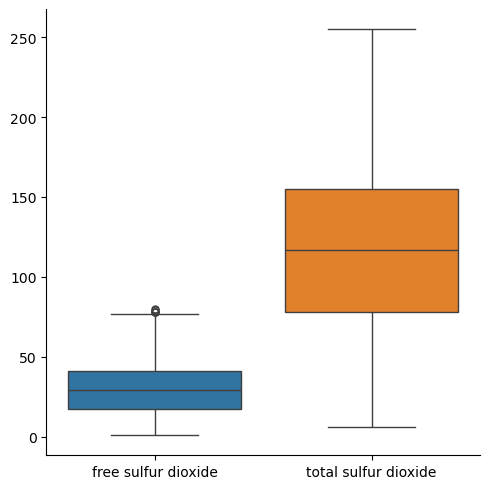

```python
sns.catplot(data = wine[['free sulfur dioxide', 'total sulfur dioxide']], kind = 'box')
```

The above plot shows that `free sulfur dioxide` is most likely some portion of `total sulfur dioxide`.

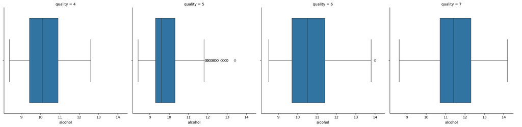

```python
sns.catplot(data = wine, x = 'alcohol', kind = 'box', col = 'quality')
```

The `alcohol` level can be analyzed by `quality` to provide an initial understanding of their relationship. Increased alcohol level has a higher grouping a data with no distinguishable additional spread.

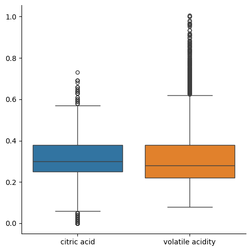

```python
sns.catplot(data = wine[['citric acid', 'volatile acidity']], kind = 'box')
```

The `citric acid` and `volatile acidity` levels show similar grouping and spread of data. This gives a possible correlation to be explored later.

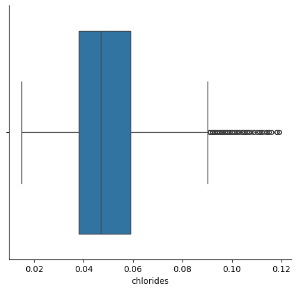

```python
sns.catplot(data = wine, x = 'chlorides', kind = 'box')
```

The plot of `chlorides` shows outliers beyond the maximum value of the dataset for the combined dataset. This is possibly due to a difference between the chemical makeup between red and white wines. The relationship can be further examined to determine if the chloride level can be used to predict the type of wine.

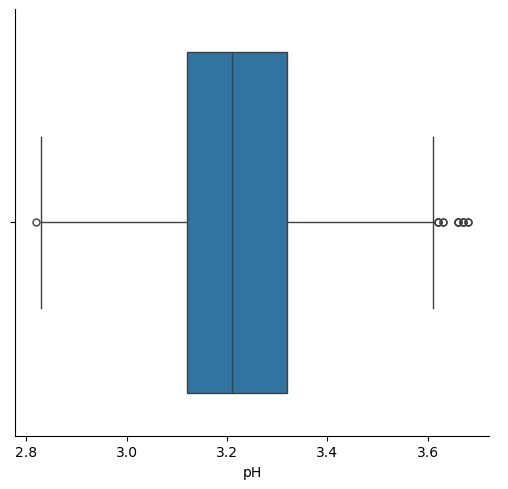

```python
sns.catplot(data = wine, x = 'pH', kind = 'box')
```

The pH of the wine samples sits around 3.2 and has little variability across red and white wine.

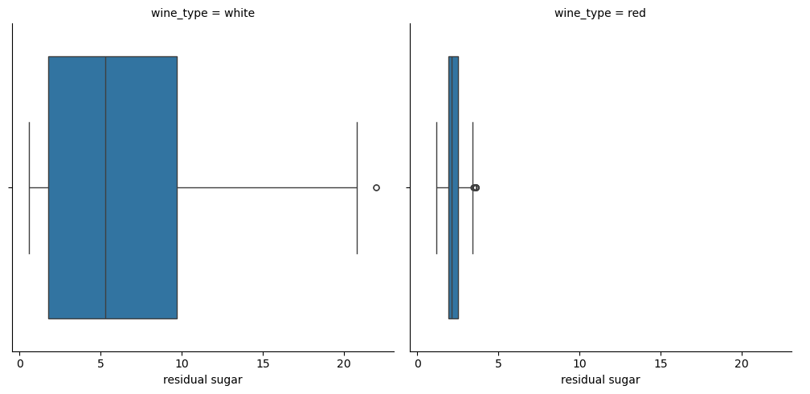

```python
sns.catplot(data = wine, x = 'residual sugar', kind = 'box', col = 'wine_type')
```

The `residual_sugar` plot separated by the wine type that red wine has lower residual sugar levels and very little spread. White wine residual sugar levels show comparably high variability between samples. This is a possible factor to be used later in the prediction of wine type from a sample's chemical composition.

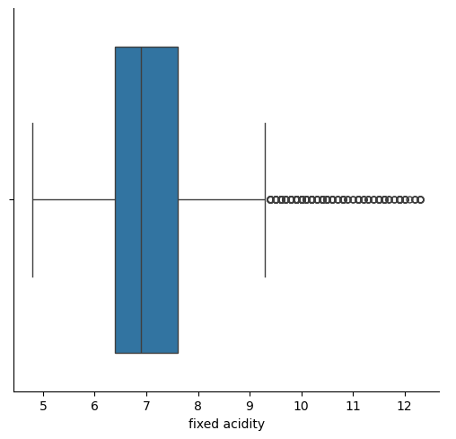

```python
sns.catplot(data = wine, x = 'fixed acidity', kind = 'box')
```

The plot of `fixed acidity` shows much higher levels than `volatile acidity` (plotted above). This corresponds with general understanding of wine chemical makeup. Wine is made from fruits, which carry high levels of acids.

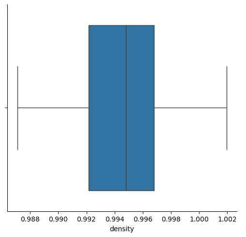

```python
sns.catplot(data = wine, x = 'density', kind = 'box')
```

The `density` plot shows that the majority of wine samples had a density of below 1, the density of water. This is expected as the density of ethanol, the other main component of wine, is less dense than water.

### Correlations

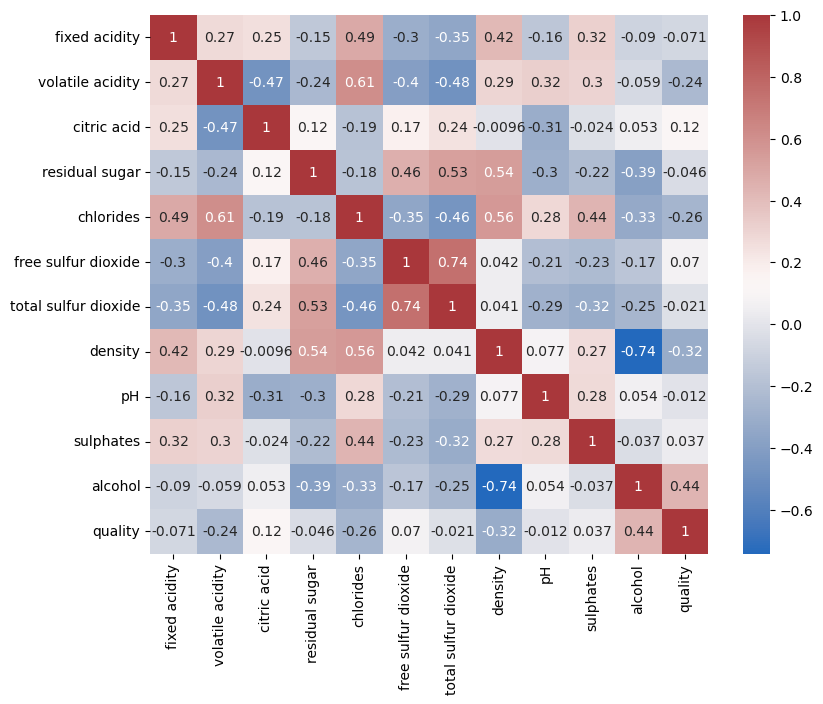

```python
plt.figure(figsize = (9, 7))
sns.heatmap(wine.drop(columns = 'wine_type').corr(), annot = True, cmap = 'vlag')
```

Correlation #1: There is a strong negative correlation (-0.74) between the amount of alcohol in the wine with the density of the wine. This can be expected as the density of alcohol is less than the density of water (the other main component of wine), so that the more alcohol the wine, the lower the density is.

Correlation #2: There is a somewhat strong negative correlation (-0.47) between the amount of citric acid and the level of volatile acidity. This is possible due to the fact that citric acid is not a volatile vapor.

Correlation #3: There is a strong positive correlation (0.74) between the amount of free sulfur dioxide and the amount of total sulfur dioxide. This is reasonable as the free sulfur dioxide is most likely a portion of the total sulfur dioxide.

## Discussion

Question #1: Can the type of wine (red vs. white) be determined based on the alcohol, residual sugar, citric acid, and chloride amounts in a sample?

Question #2: Can the quality of the wine be predicted from the pH along with the fixed acidity, volatile acidity, and sulphate amounts?